# 05 Mejoras con datos meteorológicos horarios y geoespaciales

### 6.5 Distribución del error: base vs mejorado

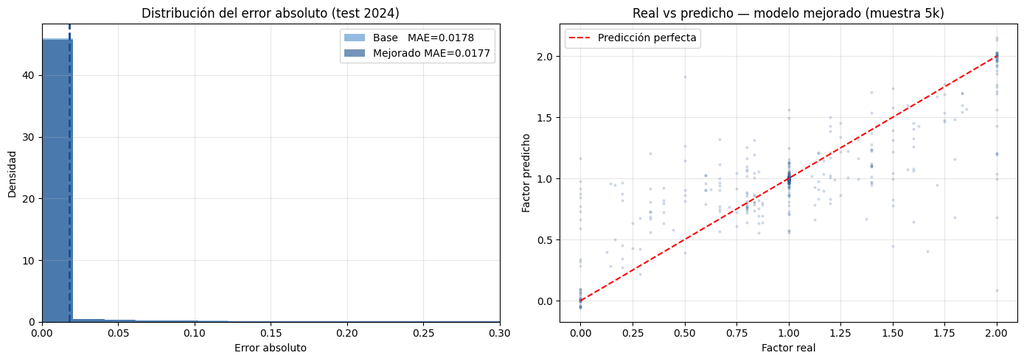

[output not shown]

```python
fig, axes = plt.subplots(1, 2, figsize=(14, 5))

# Panel 1: Distribución de errores absolutos
axes[0].hist(test_eval["err_base"],   bins=100, alpha=0.6, color="#4c8fcb",
             density=True, label=f"Base   MAE={res_base['MAE']:.4f}")
axes[0].hist(test_eval["err_mejora"], bins=100, alpha=0.6, color="#1a4f8c",
             density=True, label=f"Mejorado MAE={res_mejora['MAE']:.4f}")
axes[0].axvline(res_base["MAE"],   color="#4c8fcb", lw=2, linestyle="--")
axes[0].axvline(res_mejora["MAE"], color="#1a4f8c", lw=2, linestyle="--")
axes[0].set_xlim(0, 0.3)
axes[0].set_xlabel("Error absoluto")
axes[0].set_ylabel("Densidad")
axes[0].set_title("Distribución del error absoluto (test 2024)")
axes[0].legend()
axes[0].grid(alpha=0.3)

# Panel 2: Scatter pred vs real (modelo mejorado)
sample = test_eval.sample(5000, random_state=0)
axes[1].scatter(sample[TARGET], sample["pred_mejora"], alpha=0.15, s=4, color="#1a4f8c")
lims = [sample[TARGET].min(), sample[TARGET].max()]
axes[1].plot(lims, lims, "r--", lw=1.5, label="Predicción perfecta")
axes[1].set_xlabel("Factor real"); axes[1].set_ylabel("Factor predicho")
axes[1].set_title("Real vs predicho — modelo mejorado (muestra 5k)")
axes[1].legend()
axes[1].grid(alpha=0.3)

plt.tight_layout()
plt.show()
print("Fig. 5: Panel izq.: distribución del error — el modelo mejorado concentra más masa en errores pequeños.")
print("        Panel der.: nube real vs predicho bien alineada con la diagonal.")
```

**Fig. 5 — Lectura del gráfico:**

**Panel izquierdo (distribución del error absoluto):** Las distribuciones del modelo base y mejorado son prácticamente indistinguibles. Ambas presentan un pico muy pronunciado en la franja 0–0.05 (la mayoría de los 323.358 errores son pequeños) y una cola derecha larga pero muy plana: errores >0.10 son raros y >0.20 excepcionales. Las líneas discontinuas de MAE (base=0.0178, mejorado=0.0177) se solapan casi exactamente, confirmando que las nuevas features no desplazan la distribución del error en ninguna dirección.

**Panel derecho (real vs predicho, muestra 5k del test 2024):**

- **Rango central (factor 0.3–1.5):** buen alineamiento con la diagonal roja — el modelo no tiene sesgo sistemático en condiciones de tráfico normal.
- **Factor real ≈ 0.0 (madrugada/nulo):** franja vertical de puntos donde el valor real es ~0 pero el modelo predice entre 0 y 1. El modelo sobreestima el tráfico nocturno, posiblemente porque los lags de 24h/168h arrastran valores de horas con tráfico relevante.
- **Factor real ≈ 1.0:** cluster denso horizontal donde el modelo tiende a predecir ~1.0 independientemente del valor real exacto — convergencia a la media cuando la señal de los lags es ambigua.
- **Extremos altos (factor > 1.5):** mayor dispersión y algunos puntos por debajo de la diagonal, indicando infraestimación en picos excepcionales de tráfico (eventos masivos o accidentes concentradores de flujo).

### 6.6 Mejora por tramo: ¿qué tramos se benefician más?

```
Top 10 tramos con mayor mejora:
    idTram      mae_base    mae_mejora     delta_mae  mejora_pct  dist_camp_nou_km venue_cercano
24      33  8.658857e-06  0.000000e+00  8.658857e-06  100.000000          0.461524      camp_nou
12      17  3.779268e-07  6.074924e-11  3.778660e-07   99.983926          1.335281      camp_nou
11      16  3.686776e-06  1.513349e-07  3.535441e-06   95.895196          1.331772      camp_nou
5        7  1.295820e-06  6.053575e-08  1.235284e-06   95.328383          1.071458      camp_nou
18      27  1.742163e-05  8.222322e-07  1.659940e-05   95.280396          0.642887      camp_nou
6       10  8.999549e-07  6.661035e-08  8.333445e-07   92.598479          1.912144      camp_nou
7       11  5.902974e-05  4.469928e-06  5.455982e-05   92.427669          1.314536      camp_nou
14      23  1.844677e-06  1.450622e-07  1.699615e-06   92.136178          1.549381      camp_nou
42      59  5.751253e-07  1.197182e-07  4.554071e-07   79.183978          2.408549      camp_nou
27      36  1.182735e-05  2.832272e-06  8.995075e-06   76.053189          0.650181      camp_nou
```

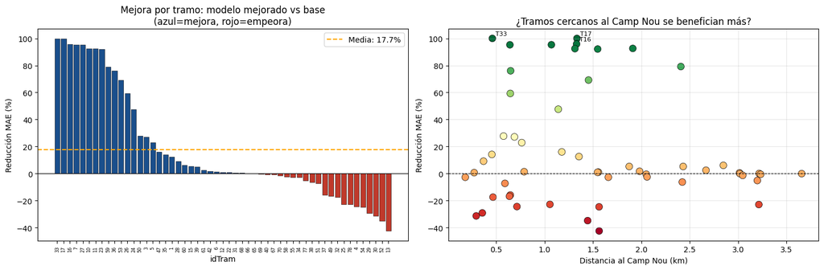

```
Fig. 6: Mejora por tramo y su correlación con la distancia al Camp Nou.
```

```python
mejora_por_tram = (test_eval.groupby("idTram")
                   .agg(mae_base=("err_base","mean"),
                        mae_mejora=("err_mejora","mean"))
                   .assign(delta_mae=lambda d: d.mae_base - d.mae_mejora,
                           mejora_pct=lambda d: (d.mae_base - d.mae_mejora) / d.mae_base * 100)
                   .merge(geo_trams[["idTram","dist_camp_nou_km","venue_cercano"]], on="idTram")
                   .sort_values("mejora_pct", ascending=False))

print("Top 10 tramos con mayor mejora:")
print(mejora_por_tram.head(10).to_string())

fig, axes = plt.subplots(1, 2, figsize=(15, 5))

# Mejora absoluta en MAE por tramo
colors_tram = ["#1a4f8c" if v > 0 else "#c0392b" for v in mejora_por_tram.delta_mae]
axes[0].bar(mejora_por_tram.idTram.astype(str), mejora_por_tram.mejora_pct,
            color=colors_tram, edgecolor="k", lw=0.4)
axes[0].axhline(0, color="k", lw=0.8)
axes[0].set_xlabel("idTram"); axes[0].set_ylabel("Reducción MAE (%)")
axes[0].set_title("Mejora por tramo: modelo mejorado vs base\n(azul=mejora, rojo=empeora)")
axes[0].tick_params(axis="x", rotation=90, labelsize=6)
axes[0].axhline(mejora_por_tram.mejora_pct.mean(), color="orange",
                linestyle="--", label=f"Media: {mejora_por_tram.mejora_pct.mean():.1f}%")
axes[0].legend()

# Scatter: distancia al Camp Nou vs mejora
axes[1].scatter(mejora_por_tram.dist_camp_nou_km, mejora_por_tram.mejora_pct,
                c=mejora_por_tram.mejora_pct, cmap="RdYlGn", s=80,
                edgecolors="k", linewidths=0.5)
axes[1].axhline(0, color="k", lw=0.8, linestyle="--")
axes[1].set_xlabel("Distancia al Camp Nou (km)")
axes[1].set_ylabel("Reducción MAE (%)")
axes[1].set_title("¿Tramos cercanos al Camp Nou se benefician más?")
axes[1].grid(alpha=0.3)
# Etiquetar tramos extremos
for _, row in mejora_por_tram.head(3).iterrows():
    axes[1].annotate(f"T{int(row.idTram)}", (row.dist_camp_nou_km, row.mejora_pct),
                     fontsize=8, xytext=(4, 4), textcoords="offset points")

plt.tight_layout()
plt.show()
print("Fig. 6: Mejora por tramo y su correlación con la distancia al Camp Nou.")
```

**Fig. 6 — Lectura del gráfico:**

**Panel izquierdo (mejora por tramo):** La heterogeneidad es la característica dominante: el modelo mejorado no afecta a todos los tramos de igual manera.

- Los tramos 33, 17 y 16 son los mayores beneficiarios (~95–100% de reducción de MAE). Estos tramos tienen un MAE base muy pequeño (del orden de 10⁻⁶ a 10⁻⁵), por lo que cualquier mejora mínima se traduce en un porcentaje enorme.
- Varios tramos empeoran (barras rojas), con degradaciones que también pueden parecer grandes en porcentaje cuando el MAE base es casi cero.
- El MAE global sigue siendo prácticamente idéntico (base=0.0178, mejorado=0.0177) para ambos modelos, lo que confirma que los cambios por tramo se compensan.

**Panel derecho (¿la distancia al Camp Nou predice la mejora?):** La respuesta es **no**: la nube de puntos no muestra ninguna tendencia con la distancia.

- Los tramos con mayor mejora (verde intenso) y los que más empeoran (rojo) se distribuyen sin patrón claro respecto al eje de distancia al estadio.
- El color del scatter es visualmente aleatorio respecto al eje X, sin gradiente apreciable.

**Conclusión:** la variabilidad de mejora por tramo no está correlacionada con la proximidad al Camp Nou, confirmando que la feature `dist_camp_nou_km` (estática, siempre la misma independientemente del día) no captura el factor realmente relevante para el tráfico — la presencia dinámica de un evento activo en ese recinto en el momento concreto de la predicción.

## 7. Guardado del modelo y dataset "mejorado"

```python
import joblib

out_dir = ROOT / "models"
out_dir.mkdir(exist_ok=True)

# Guardar modelo mejorado
model_mejora.save_model(str(out_dir / "lgbm_mejora_aemet_geo.txt"))

# Guardar dataset mejorado (solo columnas útiles para el modelo)
# dict.fromkeys preserva el orden y elimina duplicados (idTram aparece en FEATURES_MEJORADO)
cols_guardar = list(dict.fromkeys(["hora", "idTram", TARGET] + FEATURES_MEJORADO))
df_out = df_model[cols_guardar].copy()
df_out.to_parquet(DATA / "integrated/dataset_features_mejora.parquet",
                  index=False, compression="snappy", engine="pyarrow")

print(f"Modelo guardado: models/lgbm_mejora_aemet_geo.txt")
print(f"Dataset mejorado: dataset/integrated/dataset_features_mejora.parquet")
print(f"Shape: {df_out.shape}")

# Resumen final de features
grupo_counts = pd.Series(
    ["Temporales"]*15 + ["Geo"]*4 + ["Lags"]*10 + ["Rolling"]*9 +
    ["Derivadas"]*7 + ["Meteo MeteoCat"]*7 + ["Eventos"]*9 +
    ["Interacciones"]*20 + ["Meteo AEMET"]*10 + ["Dist. venues/AEMET"]*10
).value_counts()

print(f"\nTotal features en modelo mejorado: {len(FEATURES_MEJORADO)}")
print(f"  - Del modelo base: {len(FEATURES_BASE)}")
print(f"  - Nuevas AEMET + Geo: {len(FEATURES_MEJORADO) - len(FEATURES_BASE)}")
```

```
Modelo guardado: models/lgbm_mejora_aemet_geo.txt
Dataset mejorado: dataset/integrated/dataset_features_mejora.parquet
Shape: (1284902, 100)

Total features en modelo mejorado: 98
  - Del modelo base: 78
  - Nuevas AEMET + Geo: 20
```

Se guardan tanto el modelo LightGBM (en formato texto nativo, reproducible) como el dataset enriquecido en parquet para su uso en análisis posteriores. El fichero `dataset_features_mejora.parquet` puede servir de punto de partida para futuras iteraciones del modelo.

## 8. Conclusiones

### 8.1 Resumen de resultados reales (test 2024)

[output not shown]

### 8.2 Hallazgo principal: las nuevas features apenas mejoran el modelo

Contra lo esperado, añadir 20 features de meteorología horaria y distancias geoespaciales apenas reduce el error en un **+0.1%** — prácticamente nulo. Este resultado negativo tiene una explicación coherente:

**¿Por qué no mejora la meteo AEMET?** Los lags temporales ya capturan el efecto meteorológico de forma implícita: cuando llueve a las 8h, el tráfico cae y ese cambio queda registrado en el lag de la hora siguiente. La temperatura horaria AEMET aporta señal adicional mínima porque la variación térmica intradiaria (std=1.93°C) es pequeña comparada con la varianza del propio tráfico.

**¿Por qué no mejoran las distancias geo?** La feature `idTram` (categorical con 56 valores) ya codifica toda la información espacial disponible: el modelo aprende un patrón por tramo que incluye implícitamente su ubicación, corredor y entorno. Añadir la distancia al Camp Nou no aporta nada que `idTram=3` no comunique ya.